# homework5

Collin

11/13/2020

## 5

**Question 1**

**a)** *Plot the sample acf and pacf of xt and determine an appropriate ARMA model for the data.*

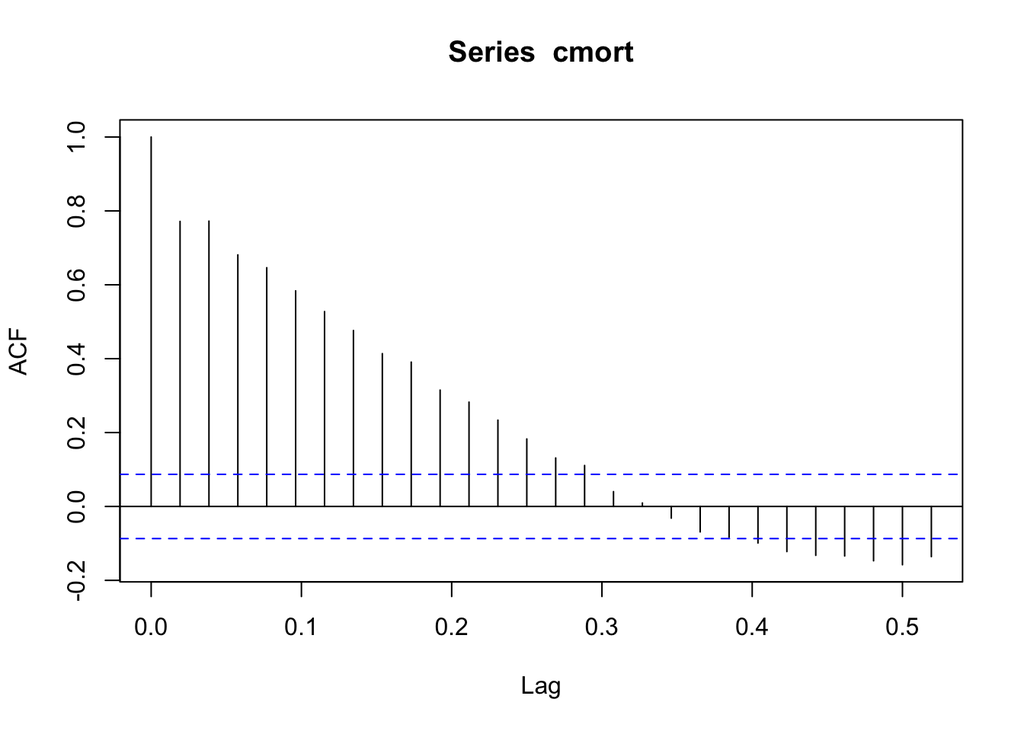

```r
acf(cmort)#doesn't look stationary
```

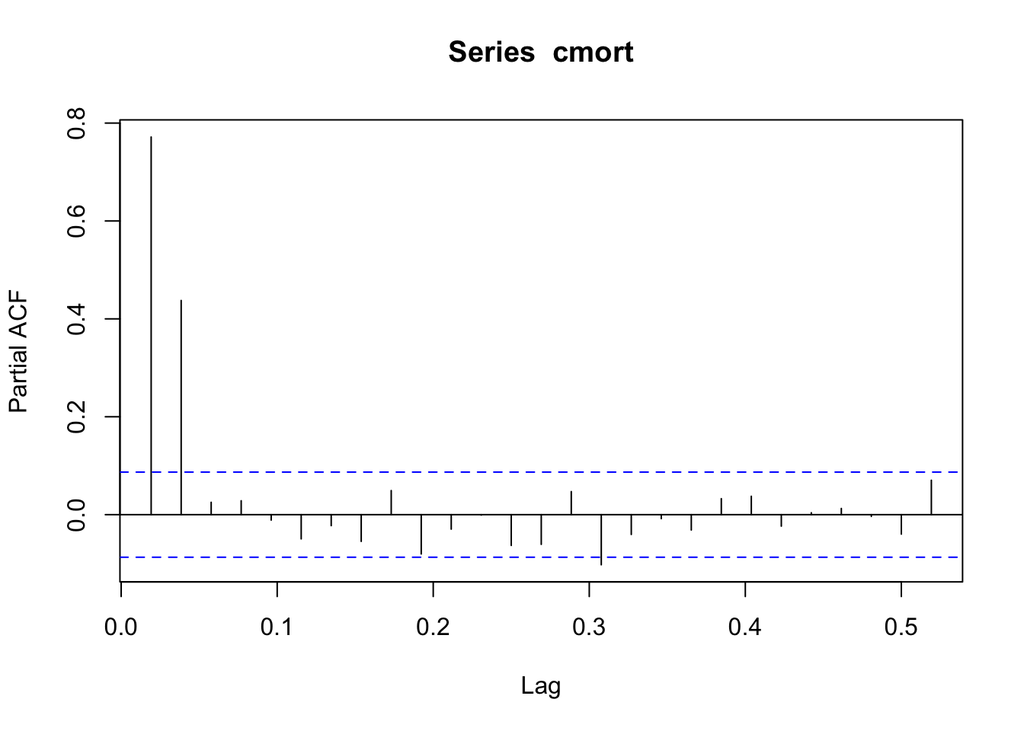

```r
pacf(cmort) #potentially an AR(2)
```

**b)** *Fit the model to the data by using the function “sarima()” in R package “astsa” and then determine the fitted model.*

```r
model =sarima(cmort,p= 2,d=0,q=0) #how do we know what order model to fit? I based it on pacf
```

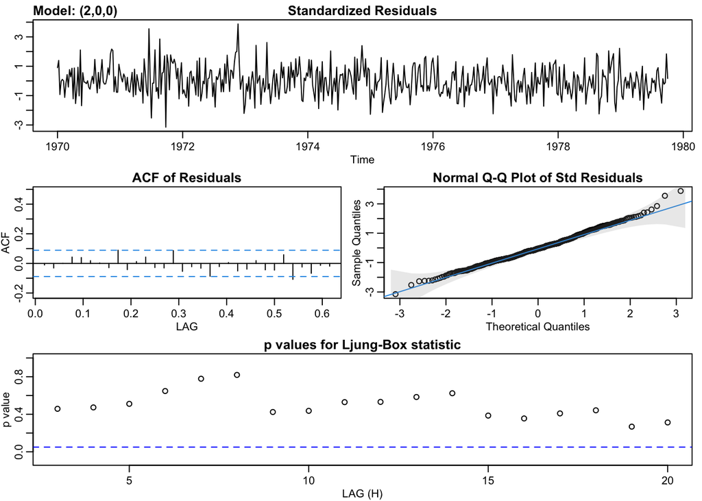

```r
str(model)
```

```
## List of 6
##  $ fit               :List of 14
##   ..$ coef     : Named num [1:3] 0.43 0.442 88.854
##   .. ..- attr(*, "names")= chr [1:3] "ar1" "ar2" "xmean"
##   ..$ sigma2   : num 32.4
##   ..$ var.coef : num [1:3, 1:3] 1.57e-03 -1.22e-03 5.46e-05 -1.22e-03 1.58e-03 ...
##   .. ..- attr(*, "dimnames")=List of 2
##   .. .. ..$ : chr [1:3] "ar1" "ar2" "xmean"
##   .. .. ..$ : chr [1:3] "ar1" "ar2" "xmean"
##   ..$ mask     : logi [1:3] TRUE TRUE TRUE
##   ..$ loglik   : num -1605
##   ..$ aic      : num 3217
##   ..$ arma     : int [1:7] 2 0 0 0 -1 0 0
##   ..$ residuals: Time-Series [1:508] from 1970 to 1980: 5.135 7.935 -5.263 -0.156 0.605 ...
##   ..$ call     : language stats::arima(x = xdata, order = c(p, d, q), seasonal = list(order = c(P,      D, Q), period = S), xreg = xmean, i| __truncated__ ...
##   ..$ series   : chr "xdata"
##   ..$ code     : int 0
##   ..$ n.cond   : int 0
##   ..$ nobs     : int 508
##   ..$ model    :List of 10
##   .. ..$ phi  : num [1:2] 0.43 0.442
##   .. ..$ theta: num 0
##   .. ..$ Delta: num(0)
##   .. ..$ Z    : num [1:2] 1 0
##   .. ..$ a    : num [1:2] -3.364 0.255
##   .. ..$ P    : num [1:2, 1:2] 0 0 0 0
##   .. ..$ T    : num [1:2, 1:2] 0.43 0.442 1 0
##   .. ..$ V    : num [1:2, 1:2] 1 0 0 0
##   .. ..$ h    : num 0
##   .. ..$ Pn   : num [1:2, 1:2] 1 0 0 0
##   ..- attr(*, "class")= chr "Arima"
##  $ degrees_of_freedom: int 505
##  $ ttable            : num [1:3, 1:4] 0.4301 0.4424 88.8538 0.0397 0.0398 ...
##   ..- attr(*, "dimnames")=List of 2
##   .. ..$ : chr [1:3] "ar1" "ar2" "xmean"
##   .. ..$ : chr [1:4] "Estimate" "SE" "t.value" "p.value"
##  $ AIC               : num 6.33
##  $ AICc              : num 6.33
##  $ BIC               : num 6.37
```

```r
model$ttable #what is the xmean output
```

```
##       Estimate     SE t.value p.value
## ar1     0.4301 0.0397 10.8404       0
## ar2     0.4424 0.0398 11.1245       0
## xmean  88.8538 1.9407 45.7839       0
```

```r
model$fit
```

```
##
## Call:
## stats::arima(x = xdata, order = c(p, d, q), seasonal = list(order = c(P, D,
##     Q), period = S), xreg = xmean, include.mean = FALSE, transform.pars = trans,
##     fixed = fixed, optim.control = list(trace = trc, REPORT = 1, reltol = tol))
##
## Coefficients:
##          ar1     ar2    xmean
##       0.4301  0.4424  88.8538
## s.e.  0.0397  0.0398   1.9407
##
## sigma^2 estimated as 32.37:  log likelihood = -1604.71,  aic = 3217.43
```

**c)** *Use the fitted model to find the 1,…,4-step-ahead prediction of the series, i.e. 𝑥𝑛𝑛+𝑘,𝑘=1,2,3,4, and compare your computation with the one obtained by applying the R function “sarima.for()”. Please show the details of your computations.*

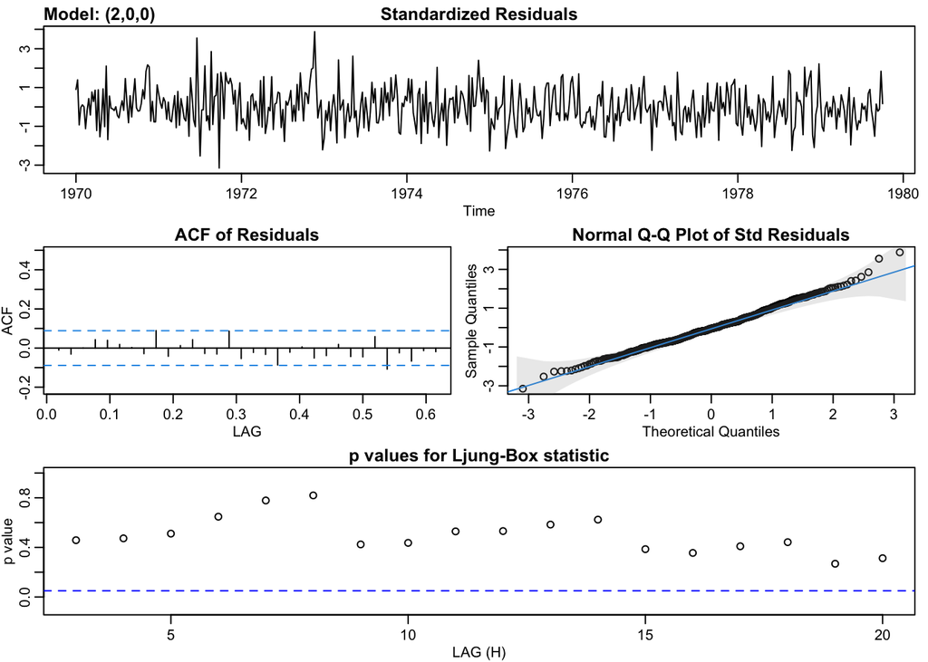

```
## $fit
##
## Call:
## stats::arima(x = xdata, order = c(p, d, q), seasonal = list(order = c(P, D,
##     Q), period = S), xreg = xmean, include.mean = FALSE, transform.pars = trans,
##     fixed = fixed, optim.control = list(trace = trc, REPORT = 1, reltol = tol))
##
## Coefficients:
##          ar1     ar2    xmean
##       0.4301  0.4424  88.8538
## s.e.  0.0397  0.0398   1.9407
##
## sigma^2 estimated as 32.37:  log likelihood = -1604.71,  aic = 3217.43
##
## $degrees_of_freedom
## [1] 505
##
## $ttable
##       Estimate     SE t.value p.value
## ar1     0.4301 0.0397 10.8404       0
## ar2     0.4424 0.0398 11.1245       0
## xmean  88.8538 1.9407 45.7839       0
##
## $AIC
## [1] 6.333521
##
## $AICc
## [1] 6.333615
##
## $BIC
## [1] 6.366832
```

```r
sarima(cmort,p= 2,d=0,q=0) #fit an arima(2,0,0) model to the cmort time series data
```

```r
pred = sarima.for(cmort,2,0,0,n.ahead = 4) #calculate the 4 step ahead predictions
```

[figure not shown]

```r
#str(pred) # I get different predicted values when I do the calculation by hand...

#sarima.for predictions:
#pred$pred


#predictions "by hand"
phi1 =  0.4301
phi2 = 0.4424
mu = 88.8538
oneStepAhead =  phi1*(85.49-88.8538) + phi2*(89.43-88.8538) + mu #add back xmean
twoStepAhead = phi1*(oneStepAhead-88.8538) + phi2*(85.49-88.8538)  + mu
threeStepAhead = phi1*(twoStepAhead-88.8538) + phi2*(oneStepAhead-88.8538) + mu
fourStepAhead = phi1*(threeStepAhead-88.8538) + phi2*(twoStepAhead-88.8538) + mu
byHandPred = c(oneStepAhead,twoStepAhead,threeStepAhead,fourStepAhead)

predDF = data.frame(sarima.for_predictions = pred$pred, by_hand_predictions = byHandPred)
rownames(predDF) = c("1 step ahead", "2 step ahead", "3 step ahead", "4 step ahead")
predDF
```

```
##              sarima.for_predictions by_hand_predictions
## 1 step ahead               87.66207            87.66194
## 2 step ahead               86.85311            86.85304
## 3 step ahead               87.46615            87.46599
## 4 step ahead               87.37190            87.37177
```

**d)** *Compute 𝑃𝑛𝑛+1,𝑃𝑛𝑛+2 and n + 3and compare it with the one produced by “sarima.for()”. Please show the details of you computations.*

```r
#the prediction error is P (MSEp)
str(pred)
```

```
## List of 2
##  $ pred: Time-Series [1:4] from 1980 to 1980: 87.7 86.9 87.5 87.4
##  $ se  : Time-Series [1:4] from 1980 to 1980: 5.69 6.19 7.15 7.61
```

```r
Pn1 = 32.37
Pn2 = Pn1*(1+(.4301)^2)
Pn3 = Pn1*(1 + (.4301)^2 + (.4424 + .4301^2)^2 )

#Pn1
Pn1
```

```
## [1] 32.37
```

```r
#Pn2
Pn2
```

```
## [1] 38.358
```

```r
#Pn3
Pn3
```

```
## [1] 51.09926
```

```r
#Here is the prediction error produced by R:


predErrorDF = data.frame(MSEp_by_hand = c(Pn1,Pn2,Pn3), se_squared = c(5.69^2,6.19^2,7.15^2))
rownames(predErrorDF) = c("n+1", "n+2","n+3")
predErrorDF
```

```
##     MSEp_by_hand se_squared
## n+1     32.37000    32.3761
## n+2     38.35800    38.3161
## n+3     51.09926    51.1225
```

Comparing the Mean Squared Error of Prediction I calculated by hand with the standard error (squared) that is outputted from the str() function call on my model, they look about the same.

**e)** *Fit an appropriate AR model to 𝑥𝑡using linear regression.*

```r
regAR = ar.ols(cmort,intercept = TRUE, order.max = 2, demean = FALSE)
summary(regAR)
```

```
##             Length Class  Mode
## order         1    -none- numeric
## ar            2    -none- numeric
## var.pred      1    -none- numeric
## x.mean        1    -none- numeric
## x.intercept   1    -none- numeric
## aic           3    -none- numeric
## n.used        1    -none- numeric
## n.obs         1    -none- numeric
## order.max     1    -none- numeric
## partialacf    0    -none- NULL
## resid       508    ts     numeric
## method        1    -none- character
## series        1    -none- character
## frequency     1    -none- numeric
## call          5    -none- call
## asy.se.coef   2    -none- list
```

```r
regAR
```

```
##
## Call:
## ar.ols(x = cmort, order.max = 2, demean = FALSE, intercept = TRUE)
##
## Coefficients:
##      1       2
## 0.4286  0.4418
##
## Intercept: 11.45 (2.394)
##
## Order selected 2  sigma^2 estimated as  32.32
```

**f)** *(f) Find the forecasts over a four week horizon, i.e. 𝑥𝑛𝑛+𝑘,𝑘=1,2,3,4. Compare your results with those obtained in part (c).*

```r
#sarima.for(regAR)

predictions = predict(regAR,n.ahead = 4)
predictions
```

```
## $pred
## Time Series:
## Start = c(1979, 41)
## End = c(1979, 44)
## Frequency = 52
## [1] 87.59986 86.76349 87.33714 87.21350
##
## $se
## Time Series:
## Start = c(1979, 41)
## End = c(1979, 44)
## Frequency = 52
## [1] 5.684848 6.184973 7.134227 7.593357
```

```r
#by hand (so to speak)
phi1 = .4286
phi2 = .4418
intercept = 11.45
oneStep = intercept + phi1*cmort[length(cmort)] +phi2*cmort[length(cmort)-1]
twoStep = intercept + phi1*oneStep + phi2*cmort[length(cmort)]
threeStep = intercept + phi1*twoStep + phi2*oneStep
fourStep = intercept + phi1*threeStep + phi2*twoStep
predictionVec = c(oneStep,twoStep,threeStep,fourStep)
predictionVec #vector of k 1...4 predictions
```

```
## [1] 87.60119 86.76535 87.33983 87.21679
```

**Question 2**

```r
#rm(list = ls())
#load data
df = read.csv("/Users/collinkennedy/Google Drive/Programming Folder (4Transfer to Collin's Files V2)/R/ATS/HW5_Q2_data.csv")

timeSeries = ts(df) #create a time series object
plot.ts(timeSeries) #plot it
```

[output not shown]

```r
acf(timeSeries) #looks to be stationary, though there is a hint of seasonality
```

[output not shown]

```r
armaOneOneFit = arima(timeSeries, order = c(1,0,1)) #should i be fitting a model with arima()

#or specifying the parameters by using arima.sim()
armaOneOneSpecified = arima(timeSeries, order = c(1, 0, 1), fixed = c(0.7, 0.4, 0.0))


sarima.for(timeSeries, n.ahead=4, p=1, d=0, q=1, fixed = c(0.7,.4,0))#how do i order the parameters in the fixed argument
```

[output not shown]

```r
#now calculating the first step ahead prediction "by hand"
piJ = ARMAtoAR(ar = .7, ma = .4, lag.max = length(timeSeries))


vecOfXs = rev(as.vector(timeSeries[1:200]))


#1 step ahead prediction right here
firstStepAhead = sum((-1)*piJ*vecOfXs)
secondStepAhead = .7*firstStepAhead
thirdStepAhead = .7*(secondStepAhead)
fourthStepAhead = .7*(thirdStepAhead)
truncPred = c(firstStepAhead,secondStepAhead,thirdStepAhead,fourthStepAhead)


presentationDF = data.frame(sarima_for_output = c(-3.429269,-2.400488,-1.680342,-1.176239),truncatedPredictionByHand = truncPred )
presentationDF
```

[output not shown]

**Question 3**

```r
df2 = read.csv("/Users/collinkennedy/Google Drive/Programming Folder (4Transfer to Collin's Files V2)/R/ATS/HW5_Q3_data.csv")

ts2 = ts(df2)
```

**a)** *plot the time series. Is there an apparent departure from stationarity?*

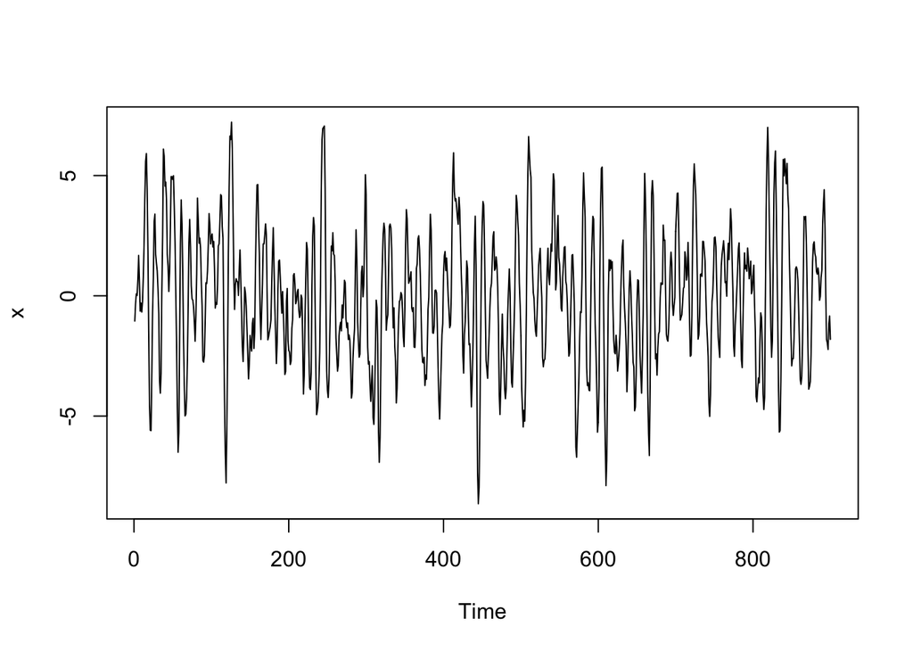

```r
plot.ts(ts2)
```

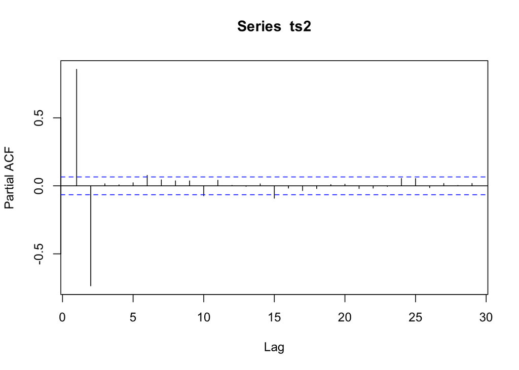

```r
pacf(ts2)
```

```r
model2 = arima(ts2, order = c(2,0,0))
model2
```

```
##
## Call:
## arima(x = ts2, order = c(2, 0, 0))
##
## Coefficients:
##          ar1      ar2  intercept
##       1.4877  -0.7365    -0.0895
## s.e.  0.0225   0.0224     0.1293
##
## sigma^2 estimated as 0.9316:  log likelihood = -1246.6,  aic = 2501.2
```

**b)** *Determine an appropriate ARMA model for the data. Explain how you determined the order of the model.*

```r
#pacf(ts2)
```

I looked at the pacf and saw that it cut off at 2 lags. This indicated it to me that it should be an AR(2) model.

**c)** *Based on your answer in part (b), estimate the parameters of the ARMA model and construct a 95% confidence interval for the estimated coefficients.*

```r
confint(model2, level = 0.95)
```

```
##                2.5 %     97.5 %
## ar1        1.4436926  1.5317271
## ar2       -0.7804930 -0.6925024
## intercept -0.3429168  0.1639736
```